# Machine Learning Project

Beecher Adams

April 2, 2017

## Overview

The goal of this project is to predict the manner in which participants did the Unilateral Dumbbell Biceps Curl exercise, which is represented by the “classe” variable in the training set. classe has the following possible values:

- Class A - exactly according to the specification
- Class B - throwing the elbows to the front
- Class C - lifting the dumbbell only halfway
- Class D - lowering the dumbbell only halfway
- Class E - throwing the hips to the front

## How the Model was Built

The model was built using the train function from the caret package. Three different models were evaluated:

- rpart - Recursive Partioning
- rf - Random Forest
- gbm - Gradient Boosting Machine

## Explanation of Choices Made

Of the three models tried, the best model was choosen by looking at the accuracy reported by the model package and the expected out of sample error. I found that it was taking a tremendously long time to do the model computation using all 19622 observations from the training data, so I reduced the training set to 5000 observations by taking a random sample. Of these 5000, 70% were used to train the model, while 30% were retained to compute the out of sample error estimate.

## Load the caret library

```r
library(caret)
```

## Read in the Training and Testing Data Files

```r
setwd("C:/Users/beecher/Documents/Coursera/MachineLearning")
training <- read.csv("pml-training.csv")
testing <- read.csv("pml-testing.csv")
```

## Do some cleanup of the data

```r
# remove columns which aren't useful for prediction

training_c <- training[ , c(8:11,37:49,84:86,113:124,151:160)]

testing_c <- testing[ , c(8:11,37:49,84:86,113:124,151:160)]
```

## Create data partitions

```r
# As mentioned to speed up model computation, reduce the original training set down to 5000 rows
# set the seed for reproducible results
set.seed(1299)
training_s <- training_c[sample(nrow(training_c), 5000),]

# split into a sub-training dataset and a sub-testing dataset
inTrain <- createDataPartition(y = training_s$classe, p = .7, list=FALSE)
training_si <- training_s[inTrain,]
testing_so <- training_s[-inTrain,]
```

## Cross-Validation Model Computations

```r
# set the seed for reproducible results
set.seed(3433)

# compute the models for the 3 different model methods

# rpart
mod_rpart <- train(classe ~ ., method="rpart", data=training_si)

# rf
mod_rf <- train(classe ~ ., method="rf", data=training_si)

# gbm
mod_gbm <- train(classe ~ ., method="gbm", data=training_si,verbose=FALSE)
```

## Estimate of Out of Sample Error

We first run the predict function on the out of sample test data and then compute the error rate.

```r
# rpart
pred_rpart <- predict(mod_rpart,testing_so)
# error
1- sum(pred_rpart == testing_so$classe) / length(pred_rpart)
```

```
## [1] 0.430954
```

```r
# rf
pred_rf <- predict(mod_rf,testing_so)
# error
1- sum(pred_rf == testing_so$classe) / length(pred_rf)
```

```
## [1] 0.03068712
```

```r
# gbm
pred_gbm <- predict(mod_gbm,testing_so)
# error
1- sum(pred_gbm == testing_so$classe) / length(pred_gbm)
```

```
## [1] 0.05470314
```

Looking at the accuracy results and out of sample errror, the Random Forest model yields the best results. We can also examine some details about the model.

```r
mod_rf$finalModel
```

```
##
## Call:
##  randomForest(x = x, y = y, mtry = param$mtry)
##                Type of random forest: classification
##                      Number of trees: 500
## No. of variables tried at each split: 2
##
##         OOB estimate of  error rate: 3.63%
## Confusion matrix:
##     A   B   C   D   E class.error
## A 966   5   1   3   1  0.01024590
## B  19 646  17   2   0  0.05555556
## C   0  19 582   9   0  0.04590164
## D   2   1  27 555   3  0.05612245
## E   1   4   6   7 625  0.02799378
```

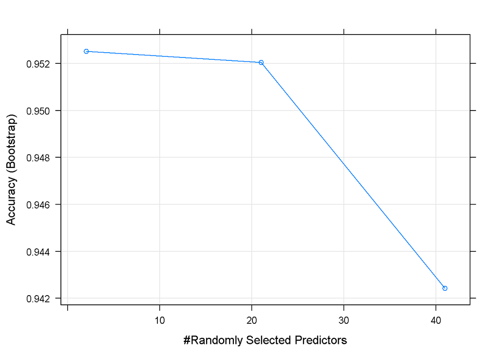

```r
plot(mod_rf)
```

Finally we’ll use the rf model on the 20 observations in the testing data set.

```r
# rf
pred_rf_testing <- predict(mod_rf,testing_c)
pred_rf_testing
```

```
##  [1] B A B A A E D B A A B C B A E E A B B B
## Levels: A B C D E
```